# **Lab 8 - K-Nearest Neighbors**

## Introduction

At the end of this laboratory, you should be able to:

- perform necessary and standard methods for classification problems (test/train split, standardization)
- perform K-nearest neighbors (KNN) algorithm on an dataset that is appropriate for classification problems
- change the parameters for KNN algorithm
- calculate the different metrics by which to evaluate a model

Reminder: you need to show your results / submit this jupyter file to have your lab credited.

Now, let us begin!

First, let us import the standard packages that we need. We might need to install some packages in python in our local drive as needed. However, this file was checked to work in Google Colab as of 2023-09-24.

For data science, on of the basic packages we will need is **scikit-learn**. Further information about this package can be found here: https://scikit-learn.org/stable/.

```python
# import packages here
import pandas as pd
import numpy as np
import sklearn
```

## Preprocessing (for classification problems)

For our first example, let us consider the classical Iris dataset. An iris is a flower, and there are different varieties/species of iris. For this class, we only consider three (based on the classical example): setosa, versicolor, or virginica.

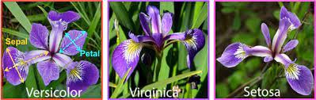

(Images taken from Reference 1.)

Classification problems require a set of features and an outcome or label. Our goal is to be able to distinguish if a flower is setosa, versicolor, or setosa (the labels, or outcomes) given a limited set of flower characteristics (the features).

For our features, we will consider the sepal length, sepal width, petal length, and petal width, and see if we can determine the species given this features.

Let us first read this file: The first code reads the file from the internet while the second assumes it is saved in the same folder as this Jupyter notebook.

```python
# Read from the internet
url='https://raw.githubusercontent.com/emmanuelplan-hsb/hsb3119_data2023/main/Iris.csv'
df_iris=pd.read_csv(url)
df_iris.head(60)
```

|  | Id | SepalLengthCm | SepalWidthCm | PetalLengthCm | PetalWidthCm | Species |
| --- | --- | --- | --- | --- | --- | --- |
| 0 | 1 | 5.1 | 3.5 | 1.4 | 0.2 | Iris-setosa |
| 1 | 2 | 4.9 | 3.0 | 1.4 | 0.2 | Iris-setosa |
| 2 | 3 | 4.7 | 3.2 | 1.3 | 0.2 | Iris-setosa |
| 3 | 4 | 4.6 | 3.1 | 1.5 | 0.2 | Iris-setosa |
| 4 | 5 | 5.0 | 3.6 | 1.4 | 0.2 | Iris-setosa |
| 5 | 6 | 5.4 | 3.9 | 1.7 | 0.4 | Iris-setosa |
| 6 | 7 | 4.6 | 3.4 | 1.4 | 0.3 | Iris-setosa |
| 7 | 8 | 5.0 | 3.4 | 1.5 | 0.2 | Iris-setosa |
| 8 | 9 | 4.4 | 2.9 | 1.4 | 0.2 | Iris-setosa |
| 9 | 10 | 4.9 | 3.1 | 1.5 | 0.1 | Iris-setosa |
| 10 | 11 | 5.4 | 3.7 | 1.5 | 0.2 | Iris-setosa |
| 11 | 12 | 4.8 | 3.4 | 1.6 | 0.2 | Iris-setosa |
| 12 | 13 | 4.8 | 3.0 | 1.4 | 0.1 | Iris-setosa |
| 13 | 14 | 4.3 | 3.0 | 1.1 | 0.1 | Iris-setosa |
| 14 | 15 | 5.8 | 4.0 | 1.2 | 0.2 | Iris-setosa |
| 15 | 16 | 5.7 | 4.4 | 1.5 | 0.4 | Iris-setosa |
| 16 | 17 | 5.4 | 3.9 | 1.3 | 0.4 | Iris-setosa |
| 17 | 18 | 5.1 | 3.5 | 1.4 | 0.3 | Iris-setosa |
| 18 | 19 | 5.7 | 3.8 | 1.7 | 0.3 | Iris-setosa |
| 19 | 20 | 5.1 | 3.8 | 1.5 | 0.3 | Iris-setosa |
| 20 | 21 | 5.4 | 3.4 | 1.7 | 0.2 | Iris-setosa |
| 21 | 22 | 5.1 | 3.7 | 1.5 | 0.4 | Iris-setosa |
| 22 | 23 | 4.6 | 3.6 | 1.0 | 0.2 | Iris-setosa |
| 23 | 24 | 5.1 | 3.3 | 1.7 | 0.5 | Iris-setosa |
| 24 | 25 | 4.8 | 3.4 | 1.9 | 0.2 | Iris-setosa |
| 25 | 26 | 5.0 | 3.0 | 1.6 | 0.2 | Iris-setosa |
| 26 | 27 | 5.0 | 3.4 | 1.6 | 0.4 | Iris-setosa |
| 27 | 28 | 5.2 | 3.5 | 1.5 | 0.2 | Iris-setosa |
| 28 | 29 | 5.2 | 3.4 | 1.4 | 0.2 | Iris-setosa |
| 29 | 30 | 4.7 | 3.2 | 1.6 | 0.2 | Iris-setosa |
| 30 | 31 | 4.8 | 3.1 | 1.6 | 0.2 | Iris-setosa |
| 31 | 32 | 5.4 | 3.4 | 1.5 | 0.4 | Iris-setosa |
| 32 | 33 | 5.2 | 4.1 | 1.5 | 0.1 | Iris-setosa |
| 33 | 34 | 5.5 | 4.2 | 1.4 | 0.2 | Iris-setosa |
| 34 | 35 | 4.9 | 3.1 | 1.5 | 0.1 | Iris-setosa |
| 35 | 36 | 5.0 | 3.2 | 1.2 | 0.2 | Iris-setosa |
| 36 | 37 | 5.5 | 3.5 | 1.3 | 0.2 | Iris-setosa |
| 37 | 38 | 4.9 | 3.1 | 1.5 | 0.1 | Iris-setosa |
| 38 | 39 | 4.4 | 3.0 | 1.3 | 0.2 | Iris-setosa |
| 39 | 40 | 5.1 | 3.4 | 1.5 | 0.2 | Iris-setosa |
| 40 | 41 | 5.0 | 3.5 | 1.3 | 0.3 | Iris-setosa |
| 41 | 42 | 4.5 | 2.3 | 1.3 | 0.3 | Iris-setosa |
| 42 | 43 | 4.4 | 3.2 | 1.3 | 0.2 | Iris-setosa |
| 43 | 44 | 5.0 | 3.5 | 1.6 | 0.6 | Iris-setosa |
| 44 | 45 | 5.1 | 3.8 | 1.9 | 0.4 | Iris-setosa |
| 45 | 46 | 4.8 | 3.0 | 1.4 | 0.3 | Iris-setosa |
| 46 | 47 | 5.1 | 3.8 | 1.6 | 0.2 | Iris-setosa |
| 47 | 48 | 4.6 | 3.2 | 1.4 | 0.2 | Iris-setosa |
| 48 | 49 | 5.3 | 3.7 | 1.5 | 0.2 | Iris-setosa |
| 49 | 50 | 5.0 | 3.3 | 1.4 | 0.2 | Iris-setosa |
| 50 | 51 | 7.0 | 3.2 | 4.7 | 1.4 | Iris-versicolor |
| 51 | 52 | 6.4 | 3.2 | 4.5 | 1.5 | Iris-versicolor |
| 52 | 53 | 6.9 | 3.1 | 4.9 | 1.5 | Iris-versicolor |
| 53 | 54 | 5.5 | 2.3 | 4.0 | 1.3 | Iris-versicolor |
| 54 | 55 | 6.5 | 2.8 | 4.6 | 1.5 | Iris-versicolor |
| 55 | 56 | 5.7 | 2.8 | 4.5 | 1.3 | Iris-versicolor |
| 56 | 57 | 6.3 | 3.3 | 4.7 | 1.6 | Iris-versicolor |
| 57 | 58 | 4.9 | 2.4 | 3.3 | 1.0 | Iris-versicolor |
| 58 | 59 | 6.6 | 2.9 | 4.6 | 1.3 | Iris-versicolor |
| 59 | 60 | 5.2 | 2.7 | 3.9 | 1.4 | Iris-versicolor |

```python
df_iris.describe()
```

|  | Id | SepalLengthCm | SepalWidthCm | PetalLengthCm | PetalWidthCm |
| --- | --- | --- | --- | --- | --- |
| count | 150.000000 | 150.000000 | 150.000000 | 150.000000 | 150.000000 |
| mean | 75.500000 | 5.843333 | 3.054000 | 3.758667 | 1.198667 |
| std | 43.445368 | 0.828066 | 0.433594 | 1.764420 | 0.763161 |
| min | 1.000000 | 4.300000 | 2.000000 | 1.000000 | 0.100000 |
| 25% | 38.250000 | 5.100000 | 2.800000 | 1.600000 | 0.300000 |
| 50% | 75.500000 | 5.800000 | 3.000000 | 4.350000 | 1.300000 |
| 75% | 112.750000 | 6.400000 | 3.300000 | 5.100000 | 1.800000 |
| max | 150.000000 | 7.900000 | 4.400000 | 6.900000 | 2.500000 |

Great! We have read the data. Before proceeding, try to understand what each column of the data means, as well as check that we do have equal number of sample from each species.

```python
df_iris[['Id','Species']].groupby('Species').count().reset_index()
```

|  | Species | Id |
| --- | --- | --- |
| 0 | Iris-setosa | 50 |
| 1 | Iris-versicolor | 50 |
| 2 | Iris-virginica | 50 |

Your turn! Now, you have a short task to separate the features (columns 2-5, named 'SepalLengthCm','SepalWidthCm','PetalLengthCm','PetalWidthCm') and the label (column name 'Species').

Save the features as (big or capital) X and the labels as (small) y.

```python
# type your code here
X=df_iris[['SepalLengthCm','SepalWidthCm','PetalLengthCm','PetalWidthCm']]
y=df_iris[['Species']]
```

The result of X.head() and y.head() should be as follows:

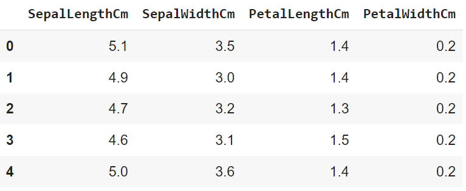

and

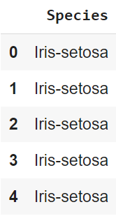

Note that the K-nearest neighbors algorithm does not accept categorical (or nominal) variables as data points, and so, we must encode our labels into numbers. In this case, the labels are assigned values 0,1,2 (respectively for the order of appearance in the label, setosa, versicolor, and virginica). Note that the code below converts y into an array (not a dataframe).

```python
from sklearn.preprocessing import LabelEncoder
le = LabelEncoder()
y = le.fit_transform(y)

y
```

```
array([0, 0, 0, 0, 0, 0, 0, 0, 0, 0, 0, 0, 0, 0, 0, 0, 0, 0, 0, 0, 0, 0,
       0, 0, 0, 0, 0, 0, 0, 0, 0, 0, 0, 0, 0, 0, 0, 0, 0, 0, 0, 0, 0, 0,
       0, 0, 0, 0, 0, 0, 1, 1, 1, 1, 1, 1, 1, 1, 1, 1, 1, 1, 1, 1, 1, 1,
       1, 1, 1, 1, 1, 1, 1, 1, 1, 1, 1, 1, 1, 1, 1, 1, 1, 1, 1, 1, 1, 1,
       1, 1, 1, 1, 1, 1, 1, 1, 1, 1, 1, 1, 2, 2, 2, 2, 2, 2, 2, 2, 2, 2,
       2, 2, 2, 2, 2, 2, 2, 2, 2, 2, 2, 2, 2, 2, 2, 2, 2, 2, 2, 2, 2, 2,
       2, 2, 2, 2, 2, 2, 2, 2, 2, 2, 2, 2, 2, 2, 2, 2, 2, 2])
```

### Visualization

Before proceeding, let us understand our data further. Let us use some built-in seaborn plots to create density plots and scatterplots:

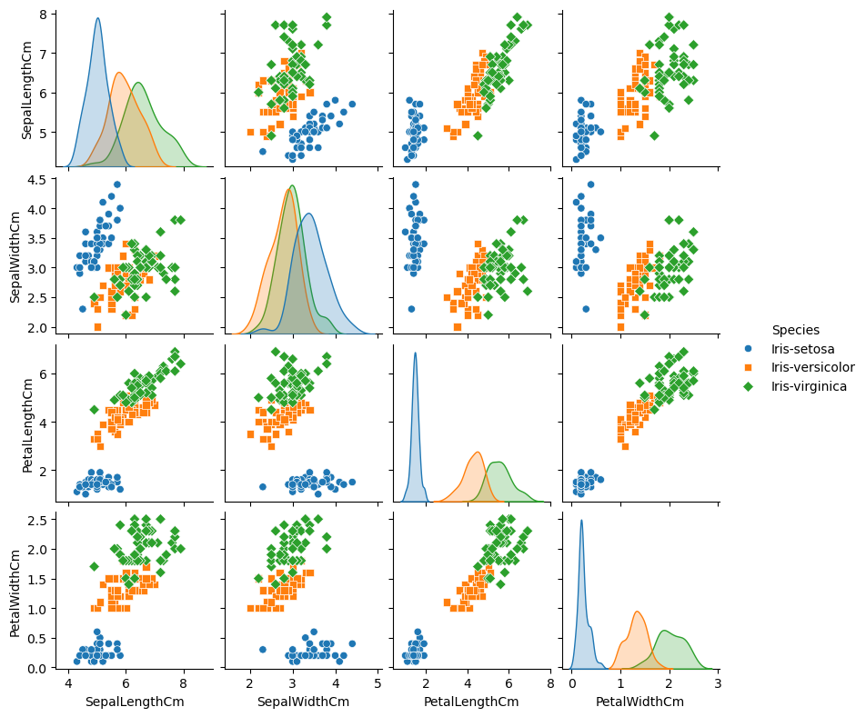

```python
import matplotlib.pyplot as plt
import seaborn as sns
%matplotlib inline

plt.figure()
sns.pairplot(df_iris.drop("Id", axis=1), hue = "Species", height=2, markers=["o", "s", "D"])
plt.show()
```

The four rows and columns arise from the number of features, while the three different colors arise from the 3 different values of the labels. What can we tell from these charts? (I'm not telling you here, but maybe I'll mention a couple in class.)

In summary, it seems that using KNN (as we understood from theory) might work.

### Train/test split

The first thing to do in a supervised learning algorithm is to separate part of your data for training purposes, and the other part of testing purposes. Scikit-learn has a special command for this, which is *train_test_split* from the submodule *model_selection*.

```python
from sklearn.model_selection import train_test_split

testperc=0.5
X_train, X_test, y_train, y_test = train_test_split(X, y, test_size = testperc, random_state = 0)

print("y_train has shape:",len(y_train))
print("y_test has shape:",len(y_test))
```

```
y_train has shape: 75
y_test has shape: 75
```

Your turn! Change the number of rows for training to be 70% of the dataset.

Then verify (by printing) that X_train and X_test have the same rows as y_train and y_test.

```python
# type your code here
```

### Standardization of values

This step is sometimes skipped when the scale of the values of the features of the dataset are approximately the same (similar means, similar standard deviations).

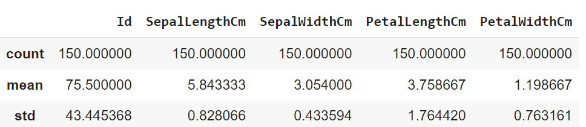

Even if it is not necessary for this case, we shall do it to demonstrate the step. The importance of this will be highlighted in the theory part/lecture.

We will only transform the X_train part because we don't want to contaminate the test data, i.e. make the testing data dirty. Here, we will use the *StandardScaler* that performs a normal or Z-transform on the variables. Alternative scalers exist.

```python
from sklearn.preprocessing import StandardScaler
scaler = StandardScaler()
scaler.fit(X_train)
print(X_train)
print(scaler.mean_) # this shows the calculated mean of X_train
X_train=scaler.transform(X_train)
print(X_train)
```

```
     SepalLengthCm  SepalWidthCm  PetalLengthCm  PetalWidthCm
3              4.6           3.1            1.5           0.2
149            5.9           3.0            5.1           1.8
98             5.1           2.5            3.0           1.1
6              4.6           3.4            1.4           0.3
68             6.2           2.2            4.5           1.5
..             ...           ...            ...           ...
9              4.9           3.1            1.5           0.1
103            6.3           2.9            5.6           1.8
67             5.8           2.7            4.1           1.0
117            7.7           3.8            6.7           2.2
47             4.6           3.2            1.4           0.2

[75 rows x 4 columns]
[5.856      3.09333333 3.664      1.16666667]
[[-1.37188119  0.01594752 -1.13425915 -1.17011609]
 [ 0.04805953 -0.22326533  0.75267844  0.76662778]
 [-0.82575014 -1.41932957 -0.34803516 -0.08069766]
 [-1.37188119  0.73358607 -1.18667408 -1.0490696 ]
 [ 0.37573816 -2.13696812  0.43818884  0.40348831]
 [ 1.46800026  1.21201177  1.27682777  1.61395322]
 [-0.17039289 -0.46247818  0.28094404  0.16139532]
 [-1.15342877 -0.22326533 -1.18667408 -1.29116258]
 [ 1.35877405 -0.22326533  1.1719979   1.12976726]
 [ 1.14032163  0.25516037  1.06716804  1.37186024]
 [ 0.70341679 -0.22326533  1.11958297  1.25081375]
 [ 0.59419058 -0.70169103  1.0147531   1.12976726]
 [-0.82575014  1.69043747 -1.08184422 -1.17011609]
 [-1.15342877  0.73358607 -1.08184422 -1.17011609]
 [ 0.70341679  0.25516037  0.75267844  1.00872077]
 [ 0.92186921  0.49437322  1.06716804  1.12976726]
 [-1.4811074  -1.89775527 -1.23908902 -1.0490696 ]
 [ 0.37573816  0.73358607  0.90992324  1.37186024]
 [-1.04420256 -0.22326533 -1.18667408 -1.17011609]
 [-0.17039289 -1.41932957  0.70026351  1.00872077]
 [ 1.14032163  0.01594752  0.90992324  1.12976726]
 [-1.59033361  0.25516037 -1.23908902 -1.17011609]
 [-0.93497635  1.21201177 -1.18667408 -1.17011609]
 [ 1.46800026 -0.22326533  1.11958297  0.5245348 ]
 [-0.82575014  0.97279892 -1.18667408 -1.0490696 ]
```

[output cut: 35 more lines]

```
 [-0.38884531 -1.65854242  0.01886938 -0.20174415]
 [ 0.92186921  0.01594752  1.0147531   1.49290673]
 [-0.06116668 -0.94090387  0.75267844  0.88767427]
 [-0.82575014  0.73358607 -1.13425915 -1.17011609]
 [ 0.812643   -0.46247818  0.49060377  0.16139532]
 [-0.2796191  -0.22326533  0.22852911  0.16139532]
 [ 0.04805953  0.25516037  0.59543364  0.76662778]
 [ 0.48496437 -1.89775527  0.38577391  0.16139532]
 [-0.38884531  0.97279892 -1.23908902 -1.17011609]
 [-0.82575014  1.45122462 -1.13425915 -0.9280231 ]
 [-1.04420256  0.01594752 -1.13425915 -1.29116258]
 [ 0.48496437 -0.46247818  1.0147531   0.76662778]
 [-0.06116668 -0.94090387  0.22852911 -0.20174415]
 [ 2.0141313   1.69043747  1.59131737  1.25081375]
 [-1.37188119  0.25516037 -1.18667408 -1.17011609]]
```

```python
#Type your code here
df_xtrain=pd.DataFrame(X_train)
df_xtrain.describe()
```

|  | 0 | 1 | 2 | 3 |
| --- | --- | --- | --- | --- |
| count | 7.500000e+01 | 7.500000e+01 | 7.500000e+01 | 7.500000e+01 |
| mean | -7.904788e-16 | 1.310063e-16 | -1.125026e-16 | -6.809368e-17 |
| std | 1.006734e+00 | 1.006734e+00 | 1.006734e+00 | 1.006734e+00 |
| min | -1.590334e+00 | -2.136968e+00 | -1.291504e+00 | -1.291163e+00 |
| 25% | -8.257501e-01 | -5.820846e-01 | -1.134259e+00 | -1.170116e+00 |
| 50% | -1.703929e-01 | 1.594752e-02 | 2.285291e-01 | 1.613953e-01 |
| 75% | 7.580299e-01 | 7.335861e-01 | 8.837158e-01 | 1.008721e+00 |
| max | 2.232584e+00 | 2.408076e+00 | 1.696147e+00 | 1.613953e+00 |

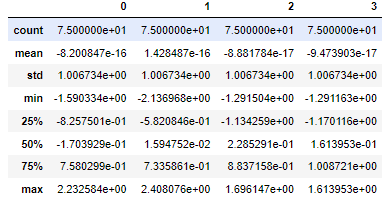

Note that we could have used the command *scaler.fit_transform(X_train)* to do both steps at the same time.

Now that the features have been transformed (and well, we did assume that the data was clean from the start), we are now ready to do a classification method (using K-Nearest Neighbors).

## Implementing K-Nearest Neighbors (KNN)

First, we initialize our model (we name it model1_knn) although it is usually called by a shorter name. Then we fit our model to the (training) data.

```python
from sklearn import neighbors

k=1
model1_knn=neighbors.KNeighborsClassifier(n_neighbors=k)

model1_knn.fit(X_train,y_train)
```

```
KNeighborsClassifier(n_neighbors=1)
```

That's it. the model has now learned and is ready to be used for prediction. Let us take a simple example. Suppose we have a flower with features [6,3,4,1], which type is it? How about a flower with features[10,3,4,1]?

```python
x_sample=[[6,3,4,1],[10,3,4,1]]
x_sample=np.array(x_sample)

x_sample=scaler.transform(x_sample)
# Note: we have to transform the training data based on the testing data
# because the model is based on the transformed dataset.

model1_knn.predict(x_sample)
# This commands predicts the labels based on the features.
```

```
array([1, 2])
```

Your turn! Let us now do this for the X_test sample.

```python
# type your code here

#y_test2= #output for x_test using the model
X_test=scaler.transform(X_test)
y_test2=model1_knn.predict(X_test)
y_test2
```

```
array([2, 1, 0, 2, 0, 2, 0, 1, 1, 1, 1, 1, 1, 1, 1, 0, 1, 1, 0, 0, 2, 1,
       0, 0, 2, 0, 0, 1, 1, 0, 2, 1, 0, 2, 2, 1, 0, 2, 1, 1, 2, 0, 2, 0,
       0, 1, 2, 2, 1, 1, 1, 2, 1, 1, 2, 2, 1, 1, 1, 2, 1, 0, 2, 1, 1, 1,
       1, 2, 0, 0, 2, 1, 0, 0, 1])
```

Compare it with the actual labels. Did we get most right?

```python
# Do the code above before running this
print(y_test)
y_test-y_test2
```

```
[2 1 0 2 0 2 0 1 1 1 2 1 1 1 1 0 1 1 0 0 2 1 0 0 2 0 0 1 1 0 2 1 0 2 2 1 0
 1 1 1 2 0 2 0 0 1 2 2 2 2 1 2 1 1 2 2 2 2 1 2 1 0 2 1 1 1 1 2 0 0 2 1 0 0
 1]
```

```
array([ 0,  0,  0,  0,  0,  0,  0,  0,  0,  0,  1,  0,  0,  0,  0,  0,  0,
        0,  0,  0,  0,  0,  0,  0,  0,  0,  0,  0,  0,  0,  0,  0,  0,  0,
        0,  0,  0, -1,  0,  0,  0,  0,  0,  0,  0,  0,  0,  0,  1,  1,  0,
        0,  0,  0,  0,  0,  1,  1,  0,  0,  0,  0,  0,  0,  0,  0,  0,  0,
        0,  0,  0,  0,  0,  0,  0])
```

What does "ytest-y_test2" show, and what does it mean?

## Evaluating our model

Nevertheless, we see that the species of most flowers were correctly identified. The first thing we usually check is "accuracy": How many of the items did we label correctly? For KNN, we do that using the following command.

```python
model1_knn.score(X_test,y_test)
```

```
0.92
```

If our accuracy is >90%, that is pretty nice!

If you want to predict stock price increase or decrease, it is difficult to do better than 60+%

However, accuracy alone gives us limited information. While we know which ones have been identified correctly and which are not, it does not tell us what kind of error we are making (and how we might want to improve).

There are two types of errors.

- A type I error is a false positive, i.e. it comes up as the label, but it actually isn't.
- A type II error is a false negative, i.e. it says it isn't the label, but it is.

For example, suppose a data point's real label is "setosa" but it comes up as not "setosa" (versicolor or virginica) then this is a false negative. In contrast, if a data point is not "setosa" but appears as "setosa", then this is a false positive.

To get a better idea of the performance of the classification model, we usually construct a confusion matrix (see notes).

In our example, it feels a bit more difficult to explain, because we have a multi-class classification problem. However, we can first make a 3x3 matrix and reduce it to a 2x2 matrix to calculate the other metrics.

Below is the code to create the confusion matrix.

```python
from sklearn.metrics import confusion_matrix
cm= confusion_matrix(y_test, y_test2)
cm
```

```
array([[21,  0,  0],
       [ 0, 29,  1],
       [ 0,  5, 19]], dtype=int64)
```

Here we can see that all the 0s (setosa) have been correctly identified. Moreover, 29 1s (versicolor) have been correctly identified.

However, 1 versicolor has been identified as 2 (virginica). 5 virginicas have been identified as 1 (versicolor).

We can calculate TP, FP, TN, FN for each of the 3 classes. Note that if there are 2 classes, the analysis is simpler. (TP = True positive, FP = False positive, TN = True negative, FN = False negative)

TP (Setosa) = 21 FP (Setosa) = 0 TN (Setosa) = 54 FN (Setosa) = 0

Tthis gives a simple 2x2 confusion matrix for Setosa as

|  | Setosa (pred) | Not (pred) |
| --- | --- | --- |
| Setosa | 21 | 0 |
| Not | 0 | 54 |

The following is the 2x2 confusion matrix for versicolor:

|  | Versicolor (pred) | Not (pred) |
| --- | --- | --- |
| Versicolor | 29 | 1 |
| Not | 5 | 40 |

### Other metrics

We now define other metrics (see notes):

- recall (positive predicted)
- precision
- specificity
- F1 score

Let us calculate this for Versicolor:

```python
recall_1=29/(29+1)
print("The model correctly predicted ",recall_1*100,"% of the actual versicolor labels correctly.\n")

precision_1=29/(29+5)
print(precision_1*100,"% of the positive output labels are correctly positive.\n")

specificity_1=40/(40+5)
print(specificity_1*100,"% of the negative output labels are correctly negative.\n")

f1_1=2*precision_1*recall_1/(precision_1+recall_1)
print("The f1 score is ",f1_1*100,"%.")
```

```
The model correctly predicted  96.66666666666667 % of the actual versicolor labels correctly.

85.29411764705883 % of the positive output labels are correctly positive.

88.88888888888889 % of the negative output labels are correctly negative.

The f1 score is  90.625 %.
```

It is also common for people to report the ROC curve, which gives the True positive rate (y) vs the false postitive rate (x). However, it only works for binary classification. Below is a typical code if our data was classified only into 2 groups.

```python
from sklearn.metrics import roc_curve, auc
from sklearn.preprocessing import label_binarize

# Binarize y_test (chuyển thành dạng nhị phân cho từng lớp)
y_test_bin = label_binarize(y_test, classes=[0, 1, 2])  # Sửa `[0, 1, 2]` thành các lớp của bạn
n_classes = y_test_bin.shape[1]

# Chọn một lớp cụ thể (ví dụ: lớp 1)
fpr, tpr, threshold = roc_curve(y_test_bin[:, 1], y_scores[:, 1])  # Lớp 1
roc_auc = auc(fpr, tpr)
```

Your turn! Construct the 2x2 confusion matrix for Virginica and calculate all the necessary values.

[output not shown]

```python
# type your code here
#url='./hsb3119data/Iris.csv'
#df_iris=pd.read_csv(url)

url='https://raw.githubusercontent.com/emmanuelplan-hsb/hsb3119_data2023/main/Iris.csv'
df_iris=pd.read_csv(url)

X=df_iris[['SepalLengthCm','SepalWidthCm','PetalLengthCm','PetalWidthCm']]
y=df_iris[['Species']]

le = LabelEncoder()
y = le.fit_transform(y)

testperc=0.2
X_train, X_test, y_train, y_test = train_test_split(X, y, test_size = testperc, random_state = 0)

scaler = StandardScaler()
scaler.fit(X_train)
X_train=scaler.transform(X_train)

k=6
model1_knn=neighbors.KNeighborsClassifier(n_neighbors=k)
model1_knn.fit(X_train,y_train)
X_test=scaler.transform(X_test)
y_test2=model1_knn.predict(X_test)

print(model1_knn.score(X_test,y_test))
cm= confusion_matrix(y_test, y_test2)
print(cm)
```

```
1.0
[[11  0  0]
 [ 0 13  0]
 [ 0  0  6]]
```

## Adjusting parameters

Here we are going to vary 2 parameters for the KNN.

1. A very obvious question is how to choose the value of $k$. To do this, it isn't difficult to loop around different values of $k$ and choose one that has the lowest error - using the desired evaluation metric above.
2. Another question is how to define the distance of one point to the other. While we didn't care about it above, there are actually different ways to calculate the distances between points. We will show the different options here.

Fortunately, there is also a command to do this easily: GridSearchCV, which tries out all combinations of the paramters. It is a form of parameter tuning.

```python
from sklearn.neighbors import KNeighborsClassifier
from sklearn.metrics import accuracy_score
from sklearn.model_selection import GridSearchCV

modelx_knn = KNeighborsClassifier()

k_range = list(range(2, 11))
param_grid = dict(n_neighbors=k_range)
param_grid.update({"metric":["minkowski","cityblock","cosine","euclidean"]})


# defining parameter range
grid = GridSearchCV(modelx_knn, param_grid, cv=2, scoring='accuracy', return_train_score=False,verbose=1)
# Gridsearch does cv=k, k-fold validation

# fitting the model for grid search
grid_search=grid.fit(X_train, y_train)

print(grid_search.best_params_)
print("The best accuracy achieved is",grid_search.best_score_ *100 )
```

```
Fitting 2 folds for each of 36 candidates, totalling 72 fits
{'metric': 'minkowski', 'n_neighbors': 8}
The best accuracy achieved is 95.83333333333333
```

Your turn! WITHOUT using GridSearchCV, create loops through different values of $k$ from 1 to 10 and different types of distance metrics (Euclidean, cityblock, cosine, minkowski), and report the accuracies (no need for other metrics). Suppose you have X and y as the original data.

After all the loops, decide which parameters are optimal based on the accuracy (Just manually choose which parameters work the best, no need to automate this part).

```python
# type your code here
url='https://raw.githubusercontent.com/emmanuelplan-hsb/hsb3119_data2023/main/Iris.csv'
df_iris=pd.read_csv(url)
Nneigh=np.arange(2,16)
metrics=["euclidean"]

# Suppose you have the data X and y already
X=df_iris[['SepalLengthCm','SepalWidthCm','PetalLengthCm','PetalWidthCm']]
y=df_iris[['Species']]

# Split into 80% training and 20% testing and fit and transform


# Prepare the loops

    # In the loop, create an instance of the the KNN classifier, \
    # then fit the training data, and predict the output

for k in Nneigh:
  for d in metrics:




    # Evaluate
    accuracy=0 #change this
    print("For k=",k,".","Accuracy is",accuracy)
```

[output not shown]

Your turn! Is higher $k$ always better? Why or why not? In this case, does it make a difference?

## Challenge 1!

Use the FIFA Women's data (2022), the one we have been using a lot in class, to predict a player is a 'SUB' or not using the column 'nation_position' based on the features: 'overall','pace','shooting','passing','dribbling','defending','physic'.

Note that you may need to relabel all other poisitions that are not 'SUB' as some other value.

Perform a train-test split using 80% of the data for training and printing all metrics, and display the ROC curve (this can be done because we only have 2 categories). Which value of k (number of neighbors) is optimal?

```python
import pandas as pd
import numpy as np
from sklearn.model_selection import train_test_split
from sklearn.neighbors import KNeighborsClassifier
from sklearn.metrics import accuracy_score, precision_score, recall_score, f1_score, roc_curve, auc, classification_report
import matplotlib.pyplot as plt
```

```python
df = pd.read_csv("fifa2022_womens_full.csv", encoding='latin1')
df.head()
```

|  | sofifa_id | player_url | short_name | long_name | player_positions | overall | potential | value_eur | wage_eur | age | ... | lcb | cb | rcb | rb | gk | player_face_url | club_logo_url | club_flag_url | nation_logo_url | nation_flag_url |
| --- | --- | --- | --- | --- | --- | --- | --- | --- | --- | --- | --- | --- | --- | --- | --- | --- | --- | --- | --- | --- | --- |
| 0 | 227246 | https://sofifa.com/player/227246/lucy-bronze/2... | L. Bronze | Lucia Roberta Tough Bronze | RB, CM | 92 | 92 | NaN | NaN | 29 | ... | 87+3 | 87+3 | 87+3 | 88+3 | 21+3 | https://cdn.sofifa.com/players/227/246/22_120.png | NaN | NaN | https://cdn.sofifa.com/teams/113002/60.png | https://cdn.sofifa.com/flags/gb-eng.png |
| 1 | 227316 | https://sofifa.com/player/227316/wendie-renard... | W. Renard | Wéndèleine Thérèse Renard | CB | 92 | 92 | NaN | NaN | 30 | ... | 90+2 | 90+2 | 90+2 | 80+3 | 20+3 | https://cdn.sofifa.com/players/227/316/22_120.png | NaN | NaN | https://cdn.sofifa.com/teams/113003/60.png | https://cdn.sofifa.com/flags/fr.png |
| 2 | 233746 | https://sofifa.com/player/233746/vivianne-mied... | V. Miedema | Vivianne Miedema | ST | 92 | 93 | NaN | NaN | 24 | ... | 52+3 | 52+3 | 52+3 | 57+3 | 24+3 | https://cdn.sofifa.com/players/233/746/22_120.png | NaN | NaN | https://cdn.sofifa.com/teams/113011/60.png | https://cdn.sofifa.com/flags/nl.png |
| 3 | 227125 | https://sofifa.com/player/227125/samantha-kerr... | S. Kerr | Samantha May Kerr | ST, LW | 91 | 91 | NaN | NaN | 27 | ... | 56+3 | 56+3 | 56+3 | 60+3 | 20+3 | https://cdn.sofifa.com/players/227/125/22_120.png | NaN | NaN | https://cdn.sofifa.com/teams/112998/60.png | https://cdn.sofifa.com/flags/au.png |
| 4 | 226301 | https://sofifa.com/player/226301/alex-morgan/2... | A. Morgan | Alexandra Morgan Carrasco | ST | 90 | 90 | NaN | NaN | 31 | ... | 56+3 | 56+3 | 56+3 | 62+3 | 19+3 | https://cdn.sofifa.com/players/226/301/22_120.png | NaN | NaN | https://cdn.sofifa.com/teams/113009/60.png | https://cdn.sofifa.com/flags/us.png |

5 rows × 110 columns

```python
print(df['nation_position'].unique())
```

[output not shown]

```python
# Kiểm tra số lượng giá trị trống trong cột 'nation_position'
print(df['nation_position'].isnull().sum())

# Kiểm tra các giá trị không phải null trong cột 'nation_position'
print(df['nation_position'].dropna().unique())
```

```
0
[]
```

```
Giá trị k tối ưu: 18, Độ chính xác cao nhất: 0.65

Classification Report:
              precision    recall  f1-score   support

           0       0.63      0.67      0.65        39
           1       0.66      0.62      0.64        40

    accuracy                           0.65        79
   macro avg       0.65      0.65      0.65        79
weighted avg       0.65      0.65      0.65        79
```

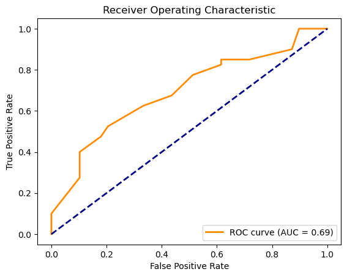

```python
df = pd.read_csv("fifa2022_womens_full.csv", encoding='latin1')
df.head()
# 1. Chuẩn bị dữ liệu
# Thay thế giá trị NaN bằng giá trị trung bình (sử dụng SimpleImputer)
features = ['overall', 'pace', 'shooting', 'passing', 'dribbling', 'defending', 'physic']
df['nation_position'] = df['nation_position'].apply(lambda x: 'SUB' if x == 'SUB' else 'OTHER')  # Nhị phân hóa
X = df[features]
y = df['nation_position']

imputer = SimpleImputer(strategy='mean')
X = imputer.fit_transform(X)

# 2. Chuyển đổi mục tiêu thành nhãn số
y = y.map({'SUB': 1, 'OTHER': 0})

# 3. Chia dữ liệu thành tập huấn luyện và kiểm tra
X_train, X_test, y_train, y_test = train_test_split(X, y, test_size=0.2, random_state=42)

# 4. Tìm giá trị k tối ưu
best_k = 1
best_score = 0
for k in range(1, 21):  # Thử nghiệm k từ 1 đến 20
    knn = KNeighborsClassifier(n_neighbors=k)
    knn.fit(X_train, y_train)
    y_pred = knn.predict(X_test)
    score = accuracy_score(y_test, y_pred)
    if score > best_score:
        best_k = k
        best_score = score

print(f"Giá trị k tối ưu: {best_k}, Độ chính xác cao nhất: {best_score:.2f}")

# 5. Huấn luyện mô hình với k tối ưu
knn = KNeighborsClassifier(n_neighbors=best_k)
knn.fit(X_train, y_train)
y_pred = knn.predict(X_test)

# 6. Đánh giá mô hình
print("\nClassification Report:")
print(classification_report(y_test, y_pred))

# 7. Tính ROC và vẽ đường cong ROC
y_scores = knn.predict_proba(X_test)[:, 1]  # Lấy xác suất dự đoán cho lớp 1
fpr, tpr, thresholds = roc_curve(y_test, y_scores)
roc_auc = auc(fpr, tpr)

plt.figure()
plt.plot(fpr, tpr, color='darkorange', lw=2, label=f'ROC curve (AUC = {roc_auc:.2f})')
plt.plot([0, 1], [0, 1], color='navy', lw=2, linestyle='--')
plt.xlabel('False Positive Rate')
plt.ylabel('True Positive Rate')
plt.title('Receiver Operating Characteristic')
plt.legend(loc="lower right")
plt.show()
```

## Challenge 2!

Sometimes, a feature is categorical and we need to perform one-hot encoding. In essence, 1 column becomes $n$ columns, where $n$ is the number of different categories. Below is an example of how to do this using an existing package using pandas "get_dummies" methods.

Use the FIFA data to include the column 'work_rate' in the features above.

```python
# Example

# Setting fake data
columns=["Company","Salary","Label"]
sampledata=[["A",10000,"Yes"],["B",12000,"Yes"],["A",8000,"No"],["C",9000,"No"]]
df_sampledata=pd.DataFrame(sampledata)
df_sampledata.columns=columns
df_sampledata
pd.get_dummies(df_sampledata,columns=["Company"])
```

|  | Salary | Label | Company_A | Company_B | Company_C |
| --- | --- | --- | --- | --- | --- |
| 0 | 10000 | Yes | 1 | 0 | 0 |
| 1 | 12000 | Yes | 0 | 1 | 0 |
| 2 | 8000 | No | 1 | 0 | 0 |
| 3 | 9000 | No | 0 | 0 | 1 |

```python
import pandas as pd

df['work_rate'] = df['work_rate'].astype('category')

# Thực hiện one-hot encoding cho cột work_rate
df_encoded = pd.get_dummies(df[features + ['work_rate']], columns=['work_rate'], drop_first=True)

# In ra kết quả
print(df_encoded.head())
```

```
   overall  pace  shooting  passing  dribbling  defending  physic  \
0       92  86.0      61.0     70.0       81.0       89.0    84.0
1       92  68.0      70.0     62.0       73.0       91.0    88.0
2       92  81.0      93.0     75.0       88.0       32.0    79.0
3       91  87.0      90.0     72.0       91.0       39.0    80.0
4       90  86.0      88.0     74.0       86.0       43.0    71.0

   work_rate_High/Low  work_rate_High/Medium  work_rate_Low/High  \
0               False                  False               False
1               False                   True               False
2                True                  False               False
3               False                   True               False
4                True                  False               False

   work_rate_Low/Medium  work_rate_Medium/High  work_rate_Medium/Low  \
0                 False                  False                 False
1                 False                  False                 False
2                 False                  False                 False
3                 False                  False                 False
4                 False                  False                 False

   work_rate_Medium/Medium
0                    False
1                    False
2                    False
3                    False
4                    False
```

```python
# type your code here
```

```python
# type your code here
```

```python
# type your code here
```

## Congratulations

You have finished this module.

## Acknowledgement, Ownership, and References

This notebook is prepared by Emmanuel Plan (emmanuelplan@hsb.edu.vn) for HSB3119: Introduction to Data Science.

## References

- Iris case study. Accessed from https://rpubs.com/vidhividhi/irisdataeda. Accessed on 21 Sept 2023

### Changelog

1. 2023-09-21: Drafted initial version
2. 2024-09-30: Improved parts of the code